# Data Manipulation with `dplyr`

## The dplry package

This lab focuses on manipulating, cleaning, and preparing data for visualization (and other analyses) using packages from the [tidyverse suite](https://www.tidyverse.org/packages/).

### Packages and Datasets

This lab will primarily use the ``dplyr` package, which is used for “data wrangling”, or the process of cleaning, restructuring, and enriching a data set to make it more usable.

```r
# Please install and load the following packages
# install.packages("dplyr")
library(dplyr)
library(ggplot2)
```

The lab will use several data sets that we’ve previously seen:

```r
colleges <- read.csv("https://grinnell-statistics.github.io/Grinnell_R_Tutorials/data/Colleges2019.csv")
bluechips = read.csv("https://grinnell-statistics.github.io/Grinnell_R_Tutorials/data/bluechips.csv")
```

## Workflow and Piping

You should strive to write code that is:

1. *Legible* - a peer could easily determine what each line is doing
2. *Efficient* - it avoids redundant, unnecessary, or computationally burdensome steps
3. *Documented* - comments and formatting are used to clearly explain every important step

Below is a *“bad” example* that begins with the `bluechips` data and creates a new data frame containing the average price (of the four stocks) for the years 2013, 2017, and 2021.

```r
## Bad example
temp1 = subset(bluechips, Year %in% c(2013, 2017, 2021))
temp2 = data.frame(Year = temp1$Year, Avg = (temp1$AAPL + temp1$KO + temp1$JNJ + temp1$AXP)/4)
temp2
```

```
##   Year       Avg
## 1 2013  46.69955
## 2 2017  65.50687
## 3 2021 114.17750
```

- Line 1 creates a new data frame that is only used in the next step (efficiency issue)
- Line 2 is doing multiple things at once without documentation (legibility and documentation issues)

We can greatly streamline our workflow in this example using a method known as **piping**:

```r
## Good example
bluechips %>%
  filter(Year %in% c(2013, 2017, 2021)) %>%    # Subset to include the target years
  mutate(Avg = (AAPL + KO + JNJ + AXP)/4) %>%  # Calculate average
  select(Year, Avg)                            # Drop everything but year and average
```

```
##   Year       Avg
## 1 2013  46.69955
## 2 2017  65.50687
## 3 2021 114.17750
```

The `%>%` symbol will “pipe” the output of a preceding function into a subsequent function (usually as the “data” argument).

Below is a description of each line within the piping example given above:

1. The data frame `bluechips` is piped forward (into the `filter()` function on the next line)
2. `filter()` subsets the data it receives to include only the target years and the resulting subset is piped forward (into the `mutate()` function on the next line)
3. `mutate()` adds a new column called “Avg” to the data frame it received, and the resulting data frame is piped forward (into the `select()` function on the next line)
4. `select()` function drops all variables other than “Year” and “Avg”

Because the output of this pipeline is not stored as an object, the final data frame is simply printed. If we planned on using data frame prepared by this pipeline in a future data visualization or model, we’d want to store it as its own object:

```r
## Storing the manipulated data set
new_bluechips <- bluechips %>%
                   filter(Year %in% c(2013, 2017, 2021)) %>%    # Include only target years
                   mutate(Avg = (AAPL + KO + JNJ + AXP)/4) %>%  # Calculate average
                   select(Year, Avg)                            # Drop extra vars
```

*Note*: all functions in the `tidyverse` suite of packages are compatible with the `%>%` operator, so we can including pivoting steps in a pipeline.

## Overview of Data Manipulation

The `dplyr` package contains a suite of functions designed to make data manipulation easier. The package’s core functions can be viewed as verbs:

| Verb/Function | Meaning |
| --- | --- |
| `filter` | pick specific observations (i.e. specific rows) similar to `subset()` |
| `arrange` | reorder the rows |
| `select` | pick variables by their names (i.e. specific columns) |
| `mutate` | add new derived columns to a data frame |
| `summarize` | aggregate many rows into a summary measure |

Importantly, these functions can be strung together using *piping*. But first, let’s see a few examples of how they work individually.

**Filter**

The `filter()` function is nearly identical to the `subset()` function from base R. The only difference is that you can provide multiple logical conditions as separate arguments (rather than building a single condition using `&`). You should also be aware of it because of its compatibility with piping.

Example:

```r
## Colleges in Iowa w/ an ACT median above 25
colleges %>% filter(State == "IA", ACT_median > 25)
```

```
##                 Name         City State Enrollment Private Region Adm_Rate
## 1    Cornell College Mount Vernon    IA       1022 Private Plains   0.6102
## 2   Drake University   Des Moines    IA       2952 Private Plains   0.6766
## 3   Grinnell College     Grinnell    IA       1683 Private Plains   0.2438
## 4     Luther College      Decorah    IA       1974 Private Plains   0.6257
## 5 University of Iowa    Iowa City    IA      23410  Public Plains   0.8267
##   ACT_median ACT_Q1 ACT_Q3  Cost Net_Tuition Avg_Fac_Salary PercentFemale
## 1         27     23     23 55817       16457          68832     0.4674157
## 2         27     24     24 53507       21160          85563     0.6097561
## 3         32     30     30 65814       20369         101979     0.5348837
## 4         26     23     23 54045       16779          67833     0.5242718
## 5         26     23     23 22607       14547          91440     0.5623043
##   PercentWhite PercentBlack PercentHispanic PercentAsian FourYearComp_Males
## 1       0.8856       0.0456          0.0595       0.0209          0.6776860
## 2       0.9025       0.0370          0.0407       0.0250          0.6641791
## 3       0.7933       0.0971          0.0841       0.0400          0.7413793
## 4       0.9335       0.0223          0.0282       0.0172          0.6457399
## 5       0.9158       0.0303          0.0377       0.0224          0.6086310
##   FourYearComp_Females Debt_median Salary10yr_median
## 1            0.7310345       22130             43000
## 2            0.7139175       19197             58300
## 3            0.8372093       15000             49100
## 4            0.7553191       25250             47400
## 5            0.6572554       16173             51900
```

**Arrange**

The `arange()` function sorts the rows of your data by one or more numeric variables:

```r
## Sort by ACT median
colleges %>%
  filter(State == "IA" & ACT_median > 25) %>%
  arrange(ACT_median)
```

```
##                 Name         City State Enrollment Private Region Adm_Rate
## 1     Luther College      Decorah    IA       1974 Private Plains   0.6257
## 2 University of Iowa    Iowa City    IA      23410  Public Plains   0.8267
## 3    Cornell College Mount Vernon    IA       1022 Private Plains   0.6102
## 4   Drake University   Des Moines    IA       2952 Private Plains   0.6766
## 5   Grinnell College     Grinnell    IA       1683 Private Plains   0.2438
##   ACT_median ACT_Q1 ACT_Q3  Cost Net_Tuition Avg_Fac_Salary PercentFemale
## 1         26     23     23 54045       16779          67833     0.5242718
## 2         26     23     23 22607       14547          91440     0.5623043
## 3         27     23     23 55817       16457          68832     0.4674157
## 4         27     24     24 53507       21160          85563     0.6097561
## 5         32     30     30 65814       20369         101979     0.5348837
##   PercentWhite PercentBlack PercentHispanic PercentAsian FourYearComp_Males
## 1       0.9335       0.0223          0.0282       0.0172          0.6457399
## 2       0.9158       0.0303          0.0377       0.0224          0.6086310
## 3       0.8856       0.0456          0.0595       0.0209          0.6776860
## 4       0.9025       0.0370          0.0407       0.0250          0.6641791
## 5       0.7933       0.0971          0.0841       0.0400          0.7413793
##   FourYearComp_Females Debt_median Salary10yr_median
## 1            0.7553191       25250             47400
## 2            0.6572554       16173             51900
## 3            0.7310345       22130             43000
## 4            0.7139175       19197             58300
## 5            0.8372093       15000             49100
```

When sorting by multiple variables, the one listed first will be given priority. Additionally, values can be arranged in descending order via the `desc()` function:

```r
## Sort by ACT median first, then by Adm_Rate among ties
IA_selective <- colleges %>%
  filter(State == "IA" & ACT_median > 25) %>%
  arrange(ACT_median, desc(Adm_Rate))
IA_selective
```

```
##                 Name         City State Enrollment Private Region Adm_Rate
## 1 University of Iowa    Iowa City    IA      23410  Public Plains   0.8267
## 2     Luther College      Decorah    IA       1974 Private Plains   0.6257
## 3   Drake University   Des Moines    IA       2952 Private Plains   0.6766
## 4    Cornell College Mount Vernon    IA       1022 Private Plains   0.6102
## 5   Grinnell College     Grinnell    IA       1683 Private Plains   0.2438
##   ACT_median ACT_Q1 ACT_Q3  Cost Net_Tuition Avg_Fac_Salary PercentFemale
## 1         26     23     23 22607       14547          91440     0.5623043
## 2         26     23     23 54045       16779          67833     0.5242718
## 3         27     24     24 53507       21160          85563     0.6097561
## 4         27     23     23 55817       16457          68832     0.4674157
## 5         32     30     30 65814       20369         101979     0.5348837
##   PercentWhite PercentBlack PercentHispanic PercentAsian FourYearComp_Males
## 1       0.9158       0.0303          0.0377       0.0224          0.6086310
## 2       0.9335       0.0223          0.0282       0.0172          0.6457399
## 3       0.9025       0.0370          0.0407       0.0250          0.6641791
## 4       0.8856       0.0456          0.0595       0.0209          0.6776860
## 5       0.7933       0.0971          0.0841       0.0400          0.7413793
##   FourYearComp_Females Debt_median Salary10yr_median
## 1            0.6572554       16173             51900
## 2            0.7553191       25250             47400
## 3            0.7139175       19197             58300
## 4            0.7310345       22130             43000
## 5            0.8372093       15000             49100
```

**Question #1**: Filter the “colleges” data to include only private colleges in the Mid East and New England regions. Then sort these schools according to the variable “PercentFemale” such that the school with the largest share of female students appears at the top of the list.

**Select**

The `select()` function is used to reduce the number of variables in a data set:

```r
# Keep only the Name, ACT_median, and Net_Tuition variables
IA_selective <- colleges %>%
  filter(State == "IA" & ACT_median > 25) %>%
  select(Name, ACT_median, Cost, Net_Tuition)
IA_selective
```

```
##                 Name ACT_median  Cost Net_Tuition
## 1    Cornell College         27 55817       16457
## 2   Drake University         27 53507       21160
## 3   Grinnell College         32 65814       20369
## 4     Luther College         26 54045       16779
## 5 University of Iowa         26 22607       14547
```

Sometimes you’ll want to keep most of your variables, dropping only a few that are no longer necessary. To drop a variable using `select()`, you can place a `-` character in front of its name:

```r
# Keep everything but the State and City variables
IA_selective <- colleges %>%
  filter(State == "IA" & ACT_median > 25) %>%
  select(-State, -City)
IA_selective
```

```
##                 Name Enrollment Private Region Adm_Rate ACT_median ACT_Q1
## 1    Cornell College       1022 Private Plains   0.6102         27     23
## 2   Drake University       2952 Private Plains   0.6766         27     24
## 3   Grinnell College       1683 Private Plains   0.2438         32     30
## 4     Luther College       1974 Private Plains   0.6257         26     23
## 5 University of Iowa      23410  Public Plains   0.8267         26     23
##   ACT_Q3  Cost Net_Tuition Avg_Fac_Salary PercentFemale PercentWhite
## 1     23 55817       16457          68832     0.4674157       0.8856
## 2     24 53507       21160          85563     0.6097561       0.9025
## 3     30 65814       20369         101979     0.5348837       0.7933
## 4     23 54045       16779          67833     0.5242718       0.9335
## 5     23 22607       14547          91440     0.5623043       0.9158
##   PercentBlack PercentHispanic PercentAsian FourYearComp_Males
## 1       0.0456          0.0595       0.0209          0.6776860
## 2       0.0370          0.0407       0.0250          0.6641791
## 3       0.0971          0.0841       0.0400          0.7413793
## 4       0.0223          0.0282       0.0172          0.6457399
## 5       0.0303          0.0377       0.0224          0.6086310
##   FourYearComp_Females Debt_median Salary10yr_median
## 1            0.7310345       22130             43000
## 2            0.7139175       19197             58300
## 3            0.8372093       15000             49100
## 4            0.7553191       25250             47400
## 5            0.6572554       16173             51900
```

**Mutate**

The `mutate()` function is used to add a new column to your data that is a function of one or more existing variables:

```r
IA_selective <- colleges %>%
  filter(State == "IA" & ACT_median > 25) %>%
  mutate(Expected_Discount = (Cost - Net_Tuition)/Cost) %>%
  select(Name, Cost, Net_Tuition, Expected_Discount)
IA_selective
```

```
##                 Name  Cost Net_Tuition Expected_Discount
## 1    Cornell College 55817       16457         0.7051615
## 2   Drake University 53507       21160         0.6045377
## 3   Grinnell College 65814       20369         0.6905066
## 4     Luther College 54045       16779         0.6895365
## 5 University of Iowa 22607       14547         0.3565267
```

In the example shown above we add a new variable, “Expected_Discount”, that is a function of “Cost” and “New_Tuition”.

**Question #2**: Using the entire “colleges” data set, create a new data frame containing *only* “Name”, “State”, and a new variable named “Debt_Cost_Ratio” that describes each college’s “Debt_median” relative to its expected cumulative cost of attendance under the assumption that a student enrolls for 4 years and “Cost” increases by 3% each year. Print this new data frame as part of your answer. *Hint*: In year 1 the cumulative cost for a student is `Cost`, in year 2 the cumulative cost is `Cost + 1.03*Cost`, etc.

**Summarize**

The `summarize()` function will calculate summary statistics that require an aggregation of rows. For example:

```r
colleges %>%
  filter(State == "IA") %>%
  summarize(Median_Cost = median(Cost))
```

```
##   Median_Cost
## 1       43520
```

Without group-wise manipulation (explained in the next section), `summarize()` is most useful for generating a customized set of summary measures:

```r
colleges %>%
  filter(State == "IA") %>%
  summarize(Min_Cost = min(Cost),
            TenPer_Cost = quantile(Cost, 0.1),     ## 10th percentile
            Median_Cost = median(Cost),
            NinetyPer_Cost = quantile(Cost, 0.9),  ## 90th percentile
            Max_Cost = max(Cost))
```

```
##   Min_Cost TenPer_Cost Median_Cost NinetyPer_Cost Max_Cost
## 1    20476     22368.2       43520        54256.2    65814
```

**Question #3**: Using the `summarize()` function, report the interquartile range (IQR) and standard deviation of the variable “Debt_Cost_Ratio” that you created in Question #2. *Hint*: recall that the IQR is calculated as the 75th percentile minus the 25th percentile.

$~$

## Group-wise Manipulation

Frequently, we’d like to perform parallel calculations for different subsets of data. For example, you might want to find the mean and standard deviation of the variable “Cost” separately for every state, or you might even want to find it separately for the private and public schools in each different state.

*Group-wise manipulation* involves two steps:

1. First, the `group_by()` function is used to internally add grouping tags to the rows of your data. You will not see these tags, but other `tidyverse` functions will recognize and use them.
2. Next, the tagged data are passed into any of the aforementioned `dplyr` functions (usually `summarize()` or `mutate()`), and those functions are executed separately on each group.

Shown below are a few examples.

In Example #1, we find the state-specific median cost of the colleges in each state located in the “Plains” region:

```r
## Example #1
colleges %>%
  filter(Region == "Plains") %>%
  group_by(State) %>%
  summarize(Median_Cost = median(Cost, na.rm = TRUE))
```

```
## # A tibble: 7 × 2
##   State Median_Cost
##   <chr>       <dbl>
## 1 IA         43520
## 2 KS         38832
## 3 MN         35887
## 4 MO         30279
## 5 ND         19299
## 6 NE         29258.
## 7 SD         22609
```

In Example #2, we find each state’s median cost separately for private and public colleges located in Iowa, Minnesota, or Missouri. We also use `n()` to count the number of colleges, recorded as “N”, belonging to each group reported in the summary.

```r
## Example #2
colleges %>%
  filter(State == "IA" | State == "MN" | State == "MO") %>%
  group_by(State, Private) %>%
  summarize(Median_Cost = median(Cost, na.rm = TRUE),
            N = n())
```

```
## # A tibble: 6 × 4
## # Groups:   State [3]
##   State Private Median_Cost     N
##   <chr> <chr>         <dbl> <int>
## 1 IA    Private      44206     25
## 2 IA    Public       21295      4
## 3 MN    Private      48860     24
## 4 MN    Public       21416     12
## 5 MO    Private      37788.    32
## 6 MO    Public       19346     13
```

```r
## Example #3
colleges %>%
  filter(State == "IA" | State == "MN" ) %>%
  group_by(State) %>%
  mutate(Cost_Avg = mean(Cost, na.rm = TRUE),
         Cost_vs_Avg = Cost - mean(Cost, na.rm = TRUE)) %>%
  select(Name, State, Cost, Cost_Avg, Cost_vs_Avg)
```

```
## # A tibble: 65 × 5
## # Groups:   State [2]
##    Name                     State  Cost Cost_Avg Cost_vs_Avg
##    <chr>                    <chr> <int>    <dbl>       <dbl>
##  1 Augsburg University      MN    51251   37714.      13537.
##  2 Bemidji State University MN    20379   37714.     -17335.
##  3 Bethany Lutheran College MN    36961   37714.       -753.
##  4 Bethel University        MN    50325   37714.      12611.
##  5 Briar Cliff University   IA    42423   41987.        436.
##  6 Buena Vista University   IA    45332   41987.       3345.
##  7 Capella University       MN    20152   37714.     -17562.
##  8 Carleton College         MN    68835   37714.      31121.
##  9 Central College          IA    50547   41987.       8560.
## 10 Clarke University        IA    44891   41987.       2904.
## # ℹ 55 more rows
```

Notice how `summarize()` returns an object with 1 row per group, while `mutate()` returns an object with 1 row per observation.

## Practice

Intensive care units, or ICUs, are primary spaces in hospitals that are reserved for patients in critical condition. The data below is a random sample of n = 200 ICU patients from a research hospital affiliated with Carnegie Mellon University (CMU).

```r
icu = read.csv("https://grinnell-statistics.github.io/Grinnell_R_Tutorials/data/ICUAdmissions.csv")
```

The data dictionary below documents each variable that was recorded:

- **ID** - Patient ID number
- **Status** - Patient status: 0=lived or 1=died
- **Age** - Patient’s age (in years)
- **Sex** - 0=male or 1=female
- **Race** - Patient’s race: 1=white, 2=black, or 3=other
- **Service** - Type of service: 0=medical or 1=surgical
- **Cancer** - Is cancer involved? 0=no or 1=yes
- **Renal** - Is chronic renal failure involved? 0=no or 1=yes
- **Infection** - Is infection involved? 0=no or 1=yes
- **CPR** - Patient received CPR prior to admission? 0=no or 1=yes
- **Systolic** - Systolic blood pressure (in mm of Hg)
- **HeartRate** - Pulse rate (beats per minute)
- **Previous** - Previous admission to ICU within 6 months? 0=no or 1=yes
- **Type** - Admission type: 0=elective or 1=emergency
- **Fracture** - Fractured bone involved? 0=no or 1=yes
- **PO2** - Partial oxygen level from blood gases under 60? 0=no or 1=yes
- **PH** - pH from blood gas under 7.25? 0=no or 1=yes
- **PCO2** - Partial carbon dioxide level from blood gas over 45? 0=no or 1=yes
- **Bicarbonate** - Bicarbonate from blood gas under 18? 0=no or 1=yes
- **Creatinine** - Creatinine from blood gas over 2.0? 0=no or 1=yes
- **Consciousness** - Level upon arrival: 0=conscious, 1=deep stupor, or 2=coma

**Question #4**:

**Part A**: Filter the ICU data to include only patients whose visit involves an infection. Then, for the “Age” variable, find the mean, standard deviation, and group size (found using the function `n()`) of patients with and without a previous admission in the prior 6 months.

**Part B**: Considering all ICU patients in these data, use the `group_by()` and `mutate()` functions to a sex-specific Z-score for the variable “HeartRate” of each patient. *Note*: you should be using different means and standard deviations within each sex to calculate this Z-score. If you are unfamiliar with Z-scores, they take the form: $Z = \tfrac{\text{Value} - \text{Mean}}{\text{Std. Dev}}$

**Part C**: Using your results from Part B, recreate the following `ggplot` graphic:

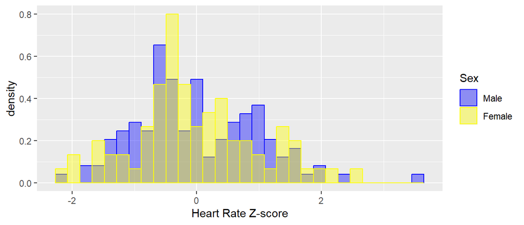